# Yield Curve

2021-9-20

# Yield Curve Project

This is one of the the several challenging projects I worked on. Yield curve is an important graph that highly related to the financial markets. Now I will walk you through what my teammates and I have worked on for this project.

First, we will load the yield curve data file that contains data on the yield curve since 1960-01-01

```r
yield_curve <- read_csv(here::here("data", "yield_curve.csv"))

glimpse(yield_curve)
```

```
## Rows: 6,884
## Columns: 5
## $ date      <date> 1960-01-01, 1960-02-01, 1960-03-01, 1960-04-01, 1960-05-01,…
## $ series_id <chr> "TB3MS", "TB3MS", "TB3MS", "TB3MS", "TB3MS", "TB3MS", "TB3MS…
## $ value     <dbl> 4.35, 3.96, 3.31, 3.23, 3.29, 2.46, 2.30, 2.30, 2.48, 2.30, …
## $ maturity  <chr> "3m", "3m", "3m", "3m", "3m", "3m", "3m", "3m", "3m", "3m", …
## $ duration  <chr> "3-Month Treasury Bill", "3-Month Treasury Bill", "3-Month T…
```

Our dataframe `yield_curve` has five columns (variables):

- `date`: already a date object
- `series_id`: the FRED database ticker symbol
- `value`: the actual yield on that date
- `maturity`: a short hand for the maturity of the bond
- `duration`: the duration, written out in all its glory!

## Plotting the yield curve

### Yields on US rates by duration since 1960

Different duration can impact the trend and the specific value of the yield curve. We thought it will be interesting to graph yields by different duration since 1960 and see the trend.

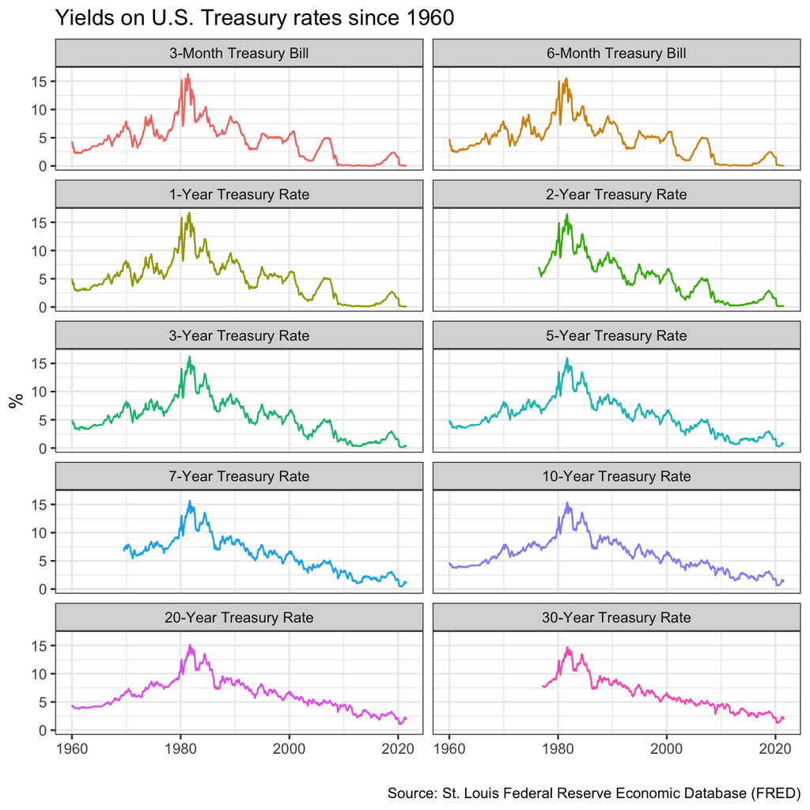

### 3-month and 10-year yields since 1999

To start with, we can see a general trend of Yields on 3-month and 10-year US Treasury rates since 1999 from the graph below:

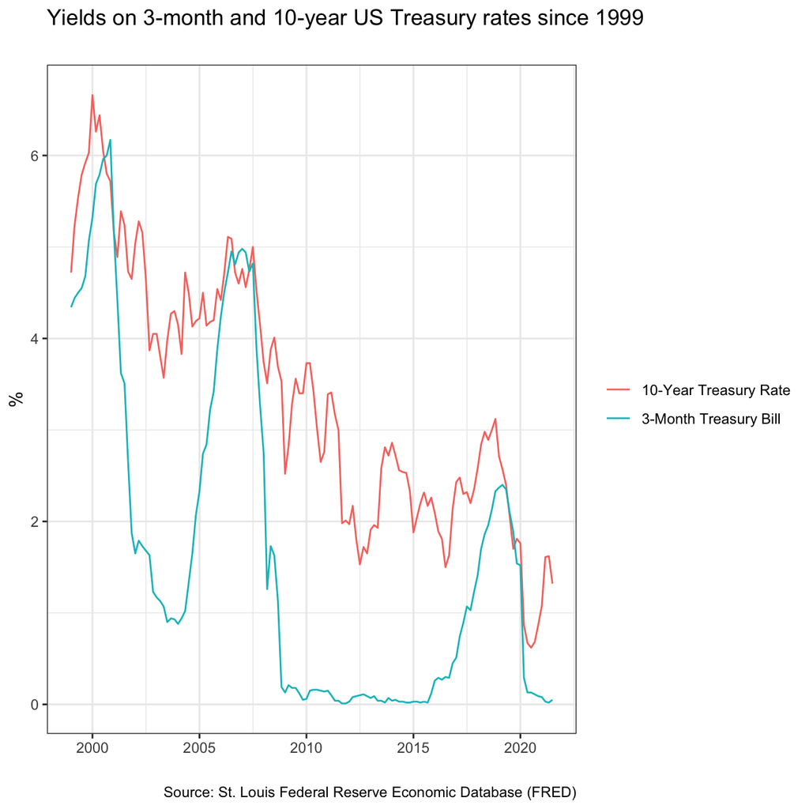

Then, we are going to identify the periods with recession and some data wrangling can help us with it. I would like to show you some behind scene work, which are some codes, first.

```r
# get US recession dates after 1946 from Wikipedia
# https://en.wikipedia.org/wiki/List_of_recessions_in_the_United_States

recessions <- tibble(
  from = c("1948-11-01", "1953-07-01", "1957-08-01", "1960-04-01", "1969-12-01", "1973-11-01", "1980-01-01","1981-07-01", "1990-07-01", "2001-03-01", "2007-12-01","2020-02-01"),
  to = c("1949-10-01", "1954-05-01", "1958-04-01", "1961-02-01", "1970-11-01", "1975-03-01", "1980-07-01", "1982-11-01", "1991-03-01", "2001-11-01", "2009-06-01", "2020-04-30")
  )  %>%
  mutate(From = ymd(from),
         To=ymd(to),
         duration_days = To-From)


recessions
```

```
## # A tibble: 12 × 5
##    from       to         From       To         duration_days
##    <chr>      <chr>      <date>     <date>     <drtn>
##  1 1948-11-01 1949-10-01 1948-11-01 1949-10-01 334 days
##  2 1953-07-01 1954-05-01 1953-07-01 1954-05-01 304 days
##  3 1957-08-01 1958-04-01 1957-08-01 1958-04-01 243 days
##  4 1960-04-01 1961-02-01 1960-04-01 1961-02-01 306 days
##  5 1969-12-01 1970-11-01 1969-12-01 1970-11-01 335 days
##  6 1973-11-01 1975-03-01 1973-11-01 1975-03-01 485 days
##  7 1980-01-01 1980-07-01 1980-01-01 1980-07-01 182 days
##  8 1981-07-01 1982-11-01 1981-07-01 1982-11-01 488 days
##  9 1990-07-01 1991-03-01 1990-07-01 1991-03-01 243 days
## 10 2001-03-01 2001-11-01 2001-03-01 2001-11-01 245 days
## 11 2007-12-01 2009-06-01 2007-12-01 2009-06-01 548 days
## 12 2020-02-01 2020-04-30 2020-02-01 2020-04-30  89 days
```

```r
recessions_new<- recessions[-c(1,2,3),]
```

Now, we are going to produce a graph that shows yield curve inversion:10-year minus 3-month U.S. Treasury rates during different time period.

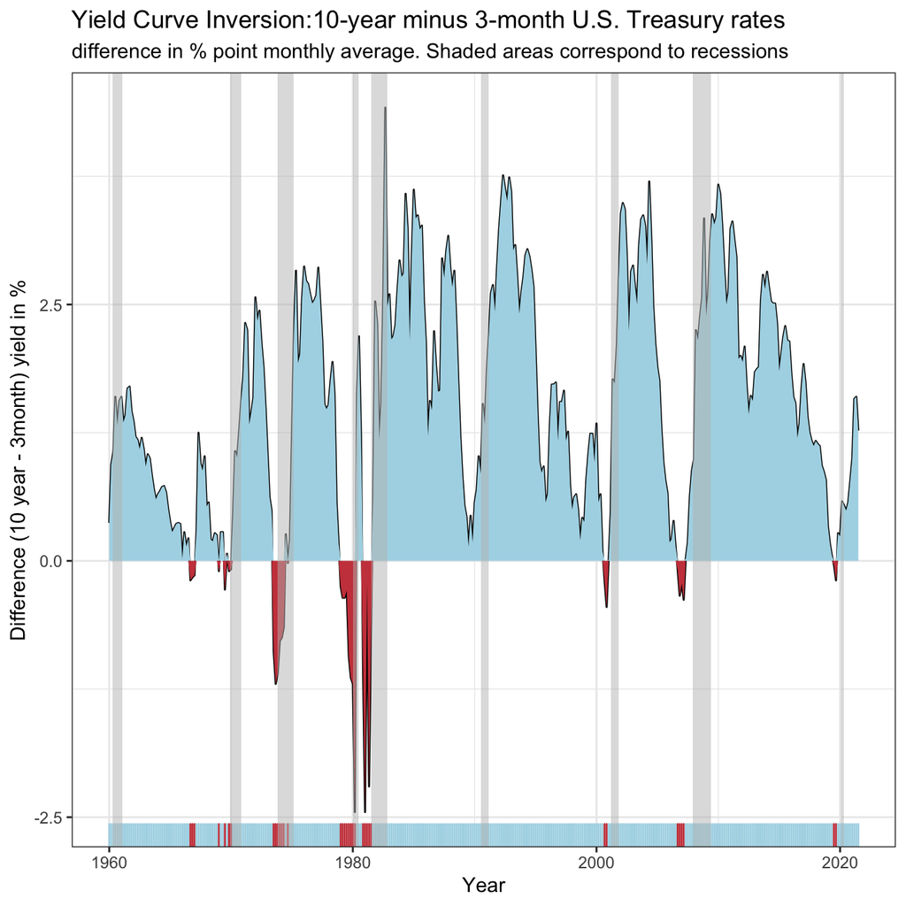

```r
data_final<- yield_curve %>%
  filter(maturity == c("3m","10y")) %>%
  select(-series_id,-duration) %>%
  pivot_wider(names_from = maturity,values_from = value)

colnames(data_final) <- c( "date","three_month","ten_year")


data_final<- data_final %>%
  mutate(diff = ten_year - three_month)%>%
  mutate(
    up =ifelse(diff>0,diff,0),
    down =ifelse(diff<0,diff,0)
  )



graph_final <- ggplot(data_final,aes(x=date,group=1))+
  geom_line(aes(y=diff))+
    theme_bw() +
  labs (
    title = "Yield Curve Inversion:10-year minus 3-month U.S. Treasury rates",
    subtitle = "difference in % point monthly average. Shaded areas correspond to recessions",
    y= "Difference (10 year - 3month) yield in %",
    x= "Year")+
  geom_ribbon(
    aes(ymin=0, ymax=up+0), fill="light blue"
  )+
geom_ribbon(
    aes(ymax=0, ymin=down+0),fill="#CB454A"
  )+
geom_rug(aes(colour=ifelse(ten_year>=three_month,">=0","<0")),sides="b")+
  scale_colour_manual(values=c("#CB454A","light blue"), guide=FALSE)+
   annotate("rect", fill = "grey", alpha = 0.5,
        xmin =recessions_new$From, xmax = recessions_new$To,
        ymin = -Inf, ymax = Inf)

graph_final
```

Thanks for reading! I hope you get some insights.